# Canadian Film Actors

Gideon Msambwa

4/7/2021

## Topic

This report will present data visualization of where the Canadian film casts are coming from. This report will help individuals seeking to meet with different film actors for mentorship and learn from them. The word casts is used in this visualization to present actors and actresses.

## Sources

This report will use the Internet Movie Database (IMDB) for film casts (https://www.kaggle.com/stefanoleone992/imdb-extensive-dataset) while geographical names data delivered from the Canadian Geographical Names Database. (https://www.nrcan.gc.ca/earth-sciences/geography/download-geographical-names-data/9245). and Shapefile comes from Natural Earth Data http://naciscdn.org/naturalearth/packages/natural_earth_vector.zip

## Obtaining Data

First, we will obtain data of Casts Names and Locations.

```r
library(tidyverse)

IMDB_names <- read_csv("IMDb names.csv")
locations <- read_csv("cgn_canada_csv_eng.csv")
```

### Formatting the Cast and Location Data

The only columns I am interested in from the IMDB_names data frames are

- Cast Name
- Date of Birth
- Place of Birth

```r
cast <- select(IMDB_names,
                name,
                date_of_birth,
                place_of_birth)
```

The goal is to have Canadian casts, so I will filter the *place_of_birth* column to contain only Canada value.

```r
canadian_cast <- filter(cast, str_detect(place_of_birth, "Canada")) %>%
  separate(place_of_birth, c("Geographical_Name", "Province", "Country"), ",")%>%
  mutate(Province = trimws(Province))%>%
  mutate(Province = gsub("C)","e",iconv(Province, 'ASCII//TRANSLIT'), fixed = TRUE))
```

Also, we will summarize the location data frame.

The column names are inconvenient, so I replace them here with names that are simpler and do not have spaces (which makes the syntax much simpler).

```r
colnames(locations) <- c("CGNDB_ID",
                      "Geographical_Name",
                      "Language",
                      "Syllabic_Form",
                      "Generic_Term",
                      "Generic_Category",
                      "Concise_Code",
                      "Toponymic",
                      "lat",
                      "long",
                      "Location",
                      "Province",
                      "Relevance_Scale",
                      "Decision_Date",
                      "Source")
```

The only columns I am interested in from the Canada_locations data frames are

- Geographical Name
- Latitude
- Longitude
- Province

```r
canada_locations<- select(locations,
                Geographical_Name,
                lat,
                long,
                Province)

ca_provinces <- select(canada_locations,
                       Province,
                       long,
                       lat) %>%
  distinct(Province, .keep_all = TRUE)
```

Then Joining the *canadian_cast* data with *canada_locations* data

```r
cast_and_location <- left_join(canadian_cast,
                                canada_locations,
                                by = c("Geographical_Name","Province"))%>%
  distinct(name, .keep_all = TRUE)%>%
  drop_na()
```

### Adding Province’s Geographical Data

Next, we will create provinces with latitude and longitude data

```r
provinces_locations <- tibble(
  lat = c(53.9333,53.7267,53.7609,46.5653,53.1355,44.6820,51.2538,46.5107,52.9399,52.9399,64.8255,70.2998,64.2823),
  long = c(-116.5765,-127.6476,-98.8139,-66.4619,-57.6604,-63.7443,-85.3232,-63.4168,-73.5491,-106.4509,-124.8457,-83.1076,-135.0000),
  province = c("Alberta", "British Columbia", "Manitoba", "New Brunswick", "Newfoundland and Labrador", "Nova Scotia", "Ontario", "Prince Edward Island", "Quebec", "Saskatchewan", "Northwest Territories", "Nunavut", "Yukon")
)

sum_by_province <- data.frame(table(cast_and_location$Province))
  colnames(sum_by_province) <- c("Province",
                      "no_of_cast")

sum_by_province = mutate(sum_by_province,
                         percent = no_of_cast/sum(no_of_cast))
```

## Visualization

Now, let’s load the shapefile

```r
library(rgdal)
library(rgeos)
library(maptools)
library(mapproj)
library(broom)

world_map <- readOGR("natural_earth_vector/50m_cultural/ne_50m_admin_1_states_provinces.shp")
canada_map <- world_map[which(world_map$admin == "Canada"),]
```

Let’s change data format

```r
canada_fortified <- fortify(canada_map, region = "name")
```

### Join the plotting data

Let’s join *canada_fortified* and *sum_by_province*

```r
cast_combined <- left_join(canada_fortified,
                          sum_by_province,
                          by = c("id" = "Province"))
```

### Create a base map

Then let’s create a base map.

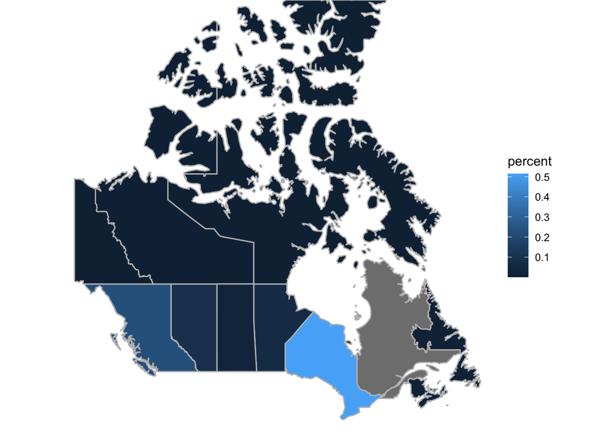

```r
canada_basemap <- ggplot(cast_combined,
                         aes(x = long,
                             y = lat)) +
  geom_polygon(aes(group = group,
                   fill = percent),
               colour = "grey") +
  theme_void() +
  coord_map()
plot(canada_basemap)
```

### Colour Scale

Let’s add a colour scale.

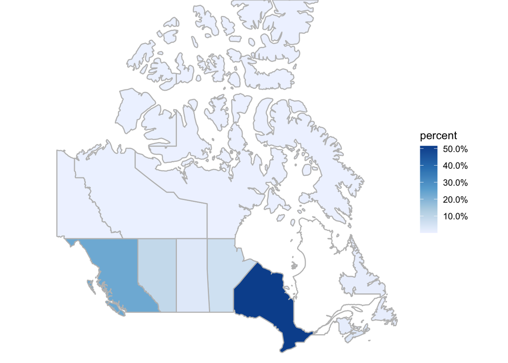

```r
library(RColorBrewer)

blues <- brewer.pal(5, "Blues")

coloured_map <- canada_basemap +
  scale_fill_gradientn(colours = blues,
                      na.value = "#FFFFFF",
                      label = scales::percent)
plot(coloured_map)
```

## Adding Data to the Map

Let’s add *cast_and_location* data to the map

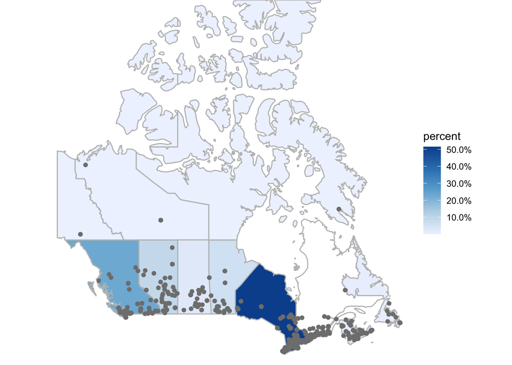

```r
castmap <- coloured_map +
  geom_point(data = cast_and_location,
             color = "gray50")
plot(castmap)
```

## Titles and Annotation

Let’s finish off the plot by showing where the Canadian film casts come from.

[figure not shown]

```r
finalmap <- castmap +
  geom_text(data = provinces_locations,
            aes(x = long,
                 y = lat,
                 label = province),
            size = 2,
            hjust = 0,
            angle = 90) +
  labs(title = "Where does Canadian Film Cast Come From?",
       subtitle = "This graphic presents a visualization of the Canadian film cast\nlocated in each province and territory of Canada. Single dots represent\nindividual film casts. The percentage of casts in each province/territory\nbased on the country's total number of film cast. The word casts is\nused in this visualization to present actors and actresses.",
       caption = "Sources: Internet Movie Database,\nCanadian Geographical Names Database, and\nNatural Earth Data\nConcept & Design: Gideon Msambwa",
       fill = "Percent of Cast\nin each Province/Territory") +
  theme(
    plot.title = element_text(hjust = 0.5, size = 14),
    plot.subtitle = element_text(hjust = 0, colour = "gray50",size = 9),
    plot.caption = element_text(hjust = 0, colour = "gray50", size = 9)
  )
plot(finalmap)
```